# IE 423 TERM PROJECT PART 2

## PART 2.1

In this part, we are expected to find out out-of-control pixel values considering the each row and each column of the matrix.

Firstly, we changed our image to using GIMP Image Editor. Then we have used “jpeg” package to store image as a variable. readJPEG() function in the jpeg package stores an image as an object in R. Our object name is “img”. You should change your image directory if you want to run our code yourself.

```r
library(jpeg)
img <- readJPEG("C:/Users/ilker zeybek/Desktop/ie423 part2/group_16grayscale.jpg", native = FALSE)
```

Then we copied our image to another variables. Purpose of these lines are to be able to make changes in one of them while we preserve original image in other.

```r
img2 <- img
img3 <- img
```

# Rows

We have constructed for() loop for storing each row at every iteration in a variable called “rows” in order to calculate their upper and lower control limits. Then we used if() statement to check if certain pixel values are out of control in it’s respective row at each iteration. After if() statement, we changed their values to 0 (black color) if there are any out of control pixels.

```r
for(i in 1:400){
for(j in 1:400){
rows <- img2[i,]
rowsucl <- mean(rows) + 3*sd(rows)
rowslcl <- mean(rows) - 3*sd(rows)
if(img2[i,j] > rowsucl | img2[i,j] < rowslcl){
img2[i,j] <- 0}}}
```

Plotting original image and changed image in same plot :

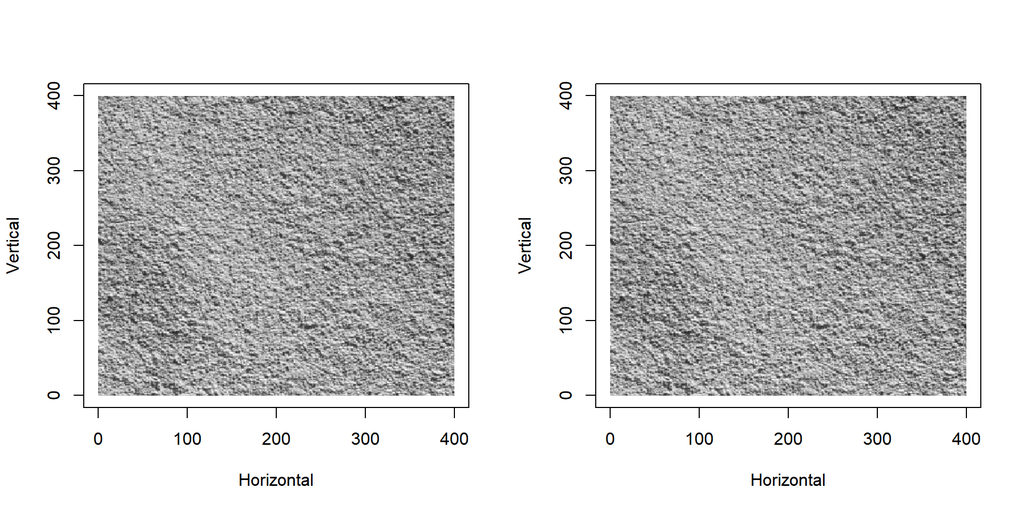

```r
par(mfrow=c(1,2))
plot(NA,xlim=c(0,nrow(img)),ylim=c(0,ncol(img)),xlab="Horizontal",ylab="Vertical")
rasterImage(img,0,0,nrow(img),ncol(img))
plot(NA,xlim=c(0,nrow(img2)),ylim=c(0,ncol(img2)),xlab="Horizontal",ylab="Vertical")
rasterImage(img2,0,0,nrow(img2),ncol(img2))
```

Since the images are hard to investigate with eyes, we checked if there are any out of control pixels with following line of code to return their indexes :

```r
img2[which(img2 == 0)]
```

```
## numeric(0)
```

Conclusion : We have expected small amount of out-of-control pixels since the image colors seemed close to each other. We have constructed 3 sigma control limits for each row mean to check our expectation. According to result, all pixels are in control with 3 sigma control limits.

# Columns

We have constructed for() loop for storing each column at every iteration in a variable called “columns” in order to calculate their upper and lower control limits. Then we used if() statement to check if certain pixel values are out of control in it’s respective column at each iteration. After if() statement, we changed their values to 0 (black color) if there are any out of control pixels.

```r
for(i in 1:400){
for(j in 1:400){
columns <- img3[,i]
columnsucl <- mean(columns) + 3*sd(columns)
columnslcl <- mean(columns) - 3*sd(columns)
if(img3[j,i] > columnsucl | img3[j,i] < columnslcl){
img3[j,i] <- 0}}}
```

Plotting original image and changed image in same plot :

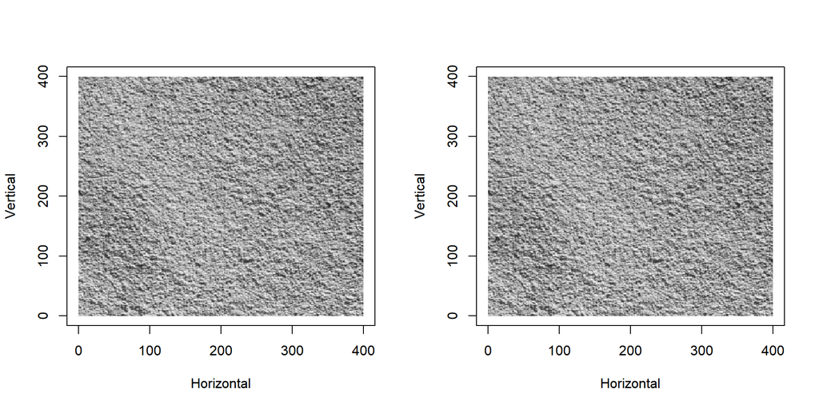

```r
par(mfrow=c(1,2))
plot(NA,xlim=c(0,nrow(img)),ylim=c(0,ncol(img)),xlab="Horizontal",ylab="Vertical")
rasterImage(img,0,0,nrow(img),ncol(img))
plot(NA,xlim=c(0,nrow(img3)),ylim=c(0,ncol(img3)),xlab="Horizontal",ylab="Vertical")
rasterImage(img3,0,0,nrow(img3),ncol(img3))
```

Since the images are hard to investigate with eyes, we checked if there are any out of control pixels with following line of code to return their indexes :

```r
img3[which(img3 == 0)]
```

```
## numeric(0)
```

## PART 2.2

We have copied our “img” variable to be able to manipulate it.

```r
img4 <- img
```

We have set a counter variable in order to indicate row number of data matrix that we store our y and x variables.

```r
counter <- 1
```

After that, we have created a dummy matrix to store our y and x variables.

```r
datamatrix <- matrix(0,nrow=4900,ncol=2601)
```

We moved our patches 5 pixels in order to avoid huge data sizes since our work computer is not good enough for huge data. By using 5 pixel intervals, we degrade the data size to 4% of 1 pixel intervals. We stored our pixels, that we are going to use in linear regression model, in datamatrix[] matrix in a for() loop.

```r
for(i in 1:69){
for(j in 1:69){
patch <- img[(5*(i-1)+1):((5*(i-1))+51),(5*(j-1)+1):((5*(j-1))+51)]
patchrows <- as.matrix(t(patch))
datamatrix[counter,] <- patchrows
counter <- counter + 1}}
```

We have created data frame with our datamatrix[] in order to use it in the lm() function. Since we have huge amount of x variables, we can not write them in lm() function one by one. Then we used lm() function to create our linear regression model for central pixels of patches.

```r
data <- data.frame(datamatrix)
model <- lm(X1301~.,data)
```

We have plotted our residuals and made a histogram of it in order to check its normality. Bell shaped curve can be observerd easily from histogram.

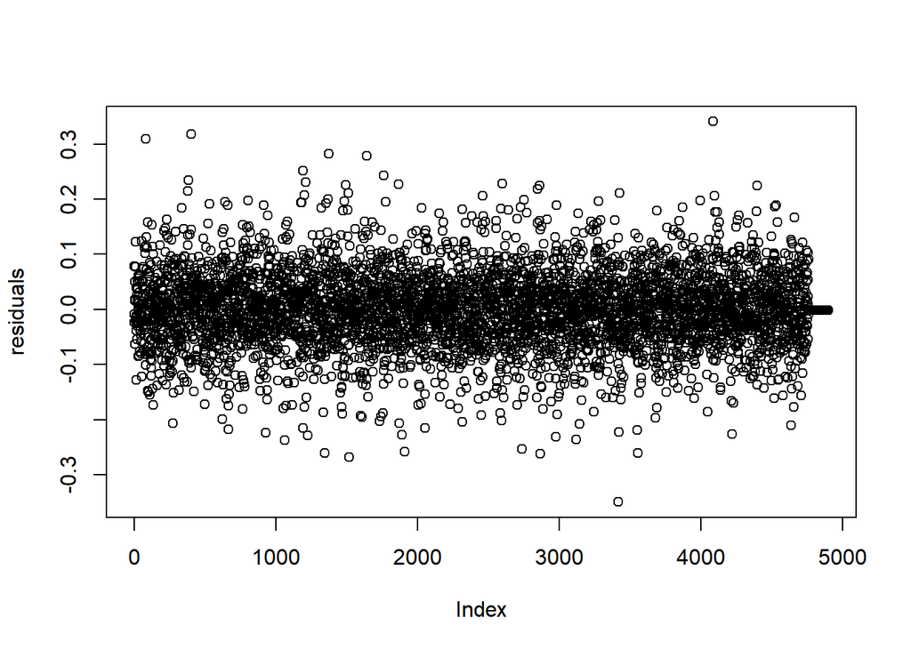

```r
residuals <- resid(model)
plot(residuals)
```

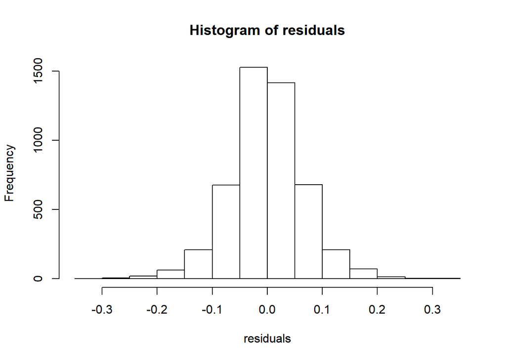

```r
hist(residuals)
```

We have found 3 sigma upper and control limits of residuals using following lines.

```r
ucl <- mean(residuals) + 3*sd(residuals)
lcl <- mean(residuals) - 3*sd(residuals)
ucl
```

```
## [1] 0.2010931
```

```r
lcl
```

```
## [1] -0.2010931
```

We used for() loop and if() statement to manipulate our image by changing out-of-control pixel values to 0 (black color).

```r
for(i in 1:70){
for(j in 1:70){
if(residuals[j+70*(i-1)] > ucl | residuals[j+70*(i-1)]< lcl){
img4[26+5*(i-1),26+5*(j-1)] <- 0}}}
```

Original image and changed image in same plot :

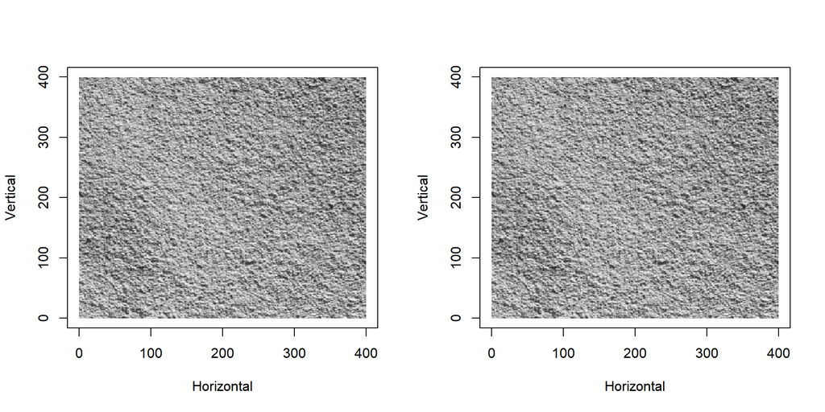

```r
par(mfrow=c(1,2))
plot(NA,xlim=c(0,nrow(img)),ylim=c(0,ncol(img)),xlab="Horizontal",ylab="Vertical")
rasterImage(img,0,0,nrow(img),ncol(img))
plot(NA,xlim=c(0,nrow(img4)),ylim=c(0,ncol(img4)),xlab="Horizontal",ylab="Vertical")
rasterImage(img4,0,0,nrow(img4),ncol(img4))
```

In order to see if there are any changed pixels we used this line of code :

```r
img4[which(img4 == 0)]
```

```
##  [1] 0 0 0 0 0 0 0 0 0 0 0 0 0 0 0 0 0 0 0 0 0 0 0 0 0 0 0 0 0 0 0 0 0 0 0
## [36] 0 0 0 0 0 0 0 0 0 0 0 0
```

Conclusion : In this process, we replaced the out of control pixels according to the central pixels by looking their control chart of residuals. There are not many black pixels in the changed image and this is why images are almost looking identical. We have assumed predictor variables are indepedent from each other. This is not an accurate assumption, therefore we can clearly say that this process is not a robust process. We are facing with multicollinearity problem in this process.

Solutions to multicollinearity problem :

1. We can remove highly-correlated predictors from the model.
2. We can use Partial Least Squares Regression
3. We can use Principal Component Analysis

Principal Component Analysis is a dimension-reduction tool that can be used to reduce a large set of variables to a small set that still contains most of the information in the large set. It transforms a number of (possibly) correlated variables into a (smaller) number of uncorrelated variables called “principal components”.

Source : ftp://statgen.ncsu.edu/pub/thorne/molevoclass/AtchleyOct19.pdf